# Project 2 B Approach

## Creating a better confusion matrix

I didn’t love the simple confusion matrix (it’s a little confusing), so I asked Gemini to help me make a better one.

```r
#install.packages("yardstick")
library(yardstick)
#Surprise! This makes exactly the same thing as the little table.

point_two %>%
    mutate(
        sex = as.factor(sex),
        threshold_outcome = as.factor(threshold_outcome)
    ) |>
    conf_mat(truth = sex, estimate = threshold_outcome)
```

```
          Truth
Prediction female male
    female     37    6
    male        2   48
```

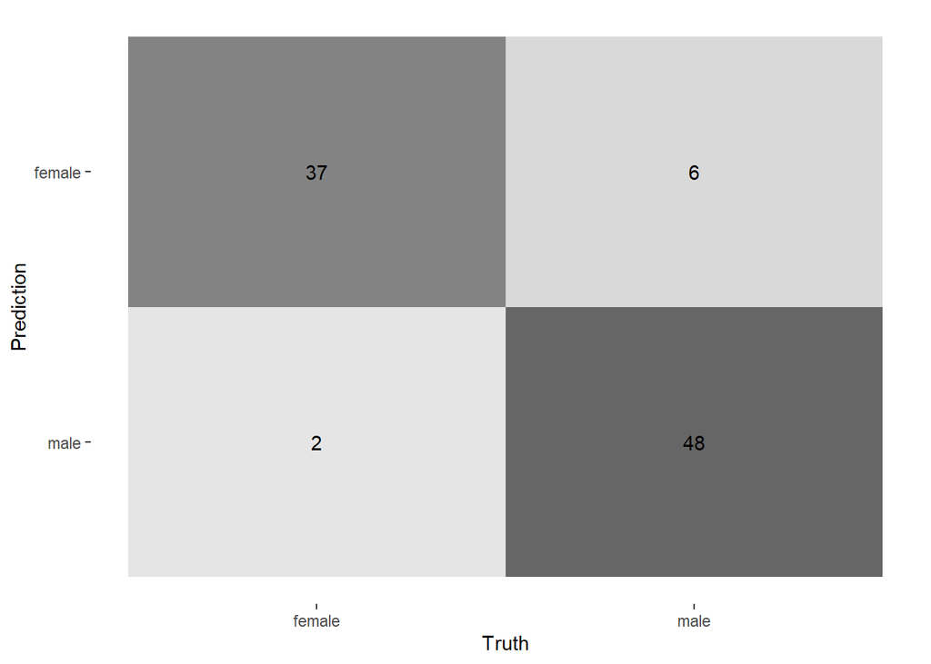

```r
#Then I tried the autoplot, which gave me this beauty
point_two %>%
    mutate(
        sex = as.factor(sex),
        threshold_outcome = as.factor(threshold_outcome)
    ) |>
    conf_mat(truth = sex, estimate = threshold_outcome) |>  autoplot(type = "heatmap")
```

[figure not shown]

```r
#I asked gemini to give it some titles and change the color, and it did this. I don't know if I love title.

point_two |>
  mutate(
    sex = as.factor(sex),
    threshold_outcome = as.factor(threshold_outcome)
  ) |>
  conf_mat(truth = sex, estimate = threshold_outcome) |>
  autoplot(type = "heatmap") +
  # 1. Change the color scale (e.g., "viridis", "magma", or custom)
  scale_fill_gradient(low = "#e6f2ff", high = "#004466") +
  # 2. Fix the labels and add a title
  labs(
    title = "Penguin Sex Prediction Results",
    subtitle = "Threshold set at 0.2",
    x = "What the Model Predicted",
    y = "The Actual Truth",
    fill = "Count"
  ) +
  # 3. Clean up the theme
  theme_minimal() +
  theme(
    panel.grid = element_blank(),
    plot.title = element_text(face = "bold", size = 14),
    axis.text = element_text(size = 12)
  )
```

[figure not shown]

```r
#I asked gemini to Change the title to Penguin Confusion Matrix and make matrices for .5 and .8

point_two |>
  mutate(
    sex = as.factor(sex),
    threshold_outcome = as.factor(threshold_outcome)
  ) |>
  conf_mat(truth = sex, estimate = threshold_outcome) |>
  autoplot(type = "heatmap") +
  scale_fill_gradient(low = "#e6f2ff", high = "#004466") +
  labs(
    title = "Penguin Sex Predictor Confusion Matrix 1",
    subtitle = "Threshold set at 0.2",
    x = "What the Model Predicted",
    y = "The Actual Truth",
    fill = "Count"
  ) +
  theme_minimal() +
  theme(
    panel.grid = element_blank(),
    plot.title = element_text(face = "bold", size = 14),
    axis.text = element_text(size = 12)
  )
```

[figure not shown]

```r
#threshold at .5
point_five |>
  mutate(
    sex = as.factor(sex),
    threshold_outcome = as.factor(threshold_outcome)
  ) |>
  conf_mat(truth = sex, estimate = threshold_outcome) |>
  autoplot(type = "heatmap") +
  scale_fill_gradient(low = "#e6f2ff", high = "#004466") +
  labs(
    title = "Penguin Sex Predictor Confusion Matrix 2",
    subtitle = "Threshold set at 0.5",
    x = "What the Model Predicted",
    y = "The Actual Truth",
    fill = "Count"
  ) +
  theme_minimal() +
  theme(
    panel.grid = element_blank(),
    plot.title = element_text(face = "bold", size = 14),
    axis.text = element_text(size = 12)
  )
```

[figure not shown]

```r
#I asked for more penguin colors for .8, and it gave me a deeper blue. That would not have been my first choice, but we're going with it.

point_eight |>
  mutate(
    sex = as.factor(sex),
    threshold_outcome = as.factor(threshold_outcome)
  ) |>
  conf_mat(truth = sex, estimate = threshold_outcome) |>
  autoplot(type = "heatmap") +
  # Using an "Ice & Deep Water" gradient
  scale_fill_gradient(low = "#F0F8FF", high = "#1B365D") +
  labs(
    title = "Penguin Sex Predictor Confusion Matrix 3",
    subtitle = "Threshold set at 0.8",
    x = "What the Model Predicted",
    y = "The Actual Truth",
    fill = "Count"
  ) +
  theme_minimal() +
  theme(
    panel.grid = element_blank(),
    plot.title = element_text(face = "bold", size = 14, color = "#1B365D"),
    axis.text = element_text(size = 12, color = "#444444"),
    # Adding a subtle "ice" colored background to the plot area
    plot.background = element_rect(fill = "#F9FDFF", color = NA)
  )
```

[output not shown]

### Probability thresholds explained

**A low probability threshold** (more false positives) is preferable in high-stakes situations, like with a carbon monoxide monitor or a mechanism that detects plane engine trouble. It’s better to have a monitor that’s too sensitive than the alternative.

**A high probability threshold** (more false negatives) is preferable in lower-stakes situations. For example, a streaming service has an algorithm that detects possible VPNs. It’s better to have more false negatives (users with VPNs accessing streaming services) than to overcorrect and deny customers services they’ve paid for.

Google Gemini. (2026). Gemini 3 Flash [Large language model].  
https://gemini.google.com. Accessed Feb 6 & 7, 2026.